# Pauses Analysis

```r
library(ggplot2)
library(corrplot)
library(lme4)
library(dplyr)
```

# Correlation Analysis

For this analysis, patients’ sentence intelligibility scores were mapped with their averaged data (manually).

Now, let’s see, whether averaged number of pauses or averaged pause duration correlate with sentence intelligibility score.

We expect that both variables will negatively correlate with sentence intelligibility score. To test this hypotheses, we use file with aggregated number of pauses and their average duration for each participant with dysarthria (except FB, which intelligibility scores are not assesed).

```r
data <- read.csv('/Users/kirillkonca/Desktop/aggregated_participant.csv', sep=';')
data <- data[, -1] # ignore first column with row numbers
```

Delete NA’s

```r
data <- na.omit(data)
```

Leave only numeric data for correlation analysis

```r
data <- data[sapply(data, is.numeric)]
```

Count correlation coefficients with Pearson method

```r
correlation_matrix <- cor(data, use = "pairwise.complete.obs")
```

```r
print(correlation_matrix)
```

```
                      avg_num_pauses avg_pause_duration speech_intelligbility
avg_num_pauses              1.000000          0.5732670            -0.2303150
avg_pause_duration          0.573267          1.0000000            -0.6476757
speech_intelligbility      -0.230315         -0.6476757             1.0000000
```

Plot correlation matrix.

For correlation threshold, we selected value of |0.6|. Average number of pauses demonstrate very weak negative correlation (PCC = -0.23) with sentence intelligibility scores. At the same time, average pause duration demonstrate moderately strong negative correlation with sentence intelligibility scores (PCC = -0.65). It is also worth mentioning that there is a noticeable positive correlation (though below our threshold, PCC = 0.57) between average number of pauses and their duration.

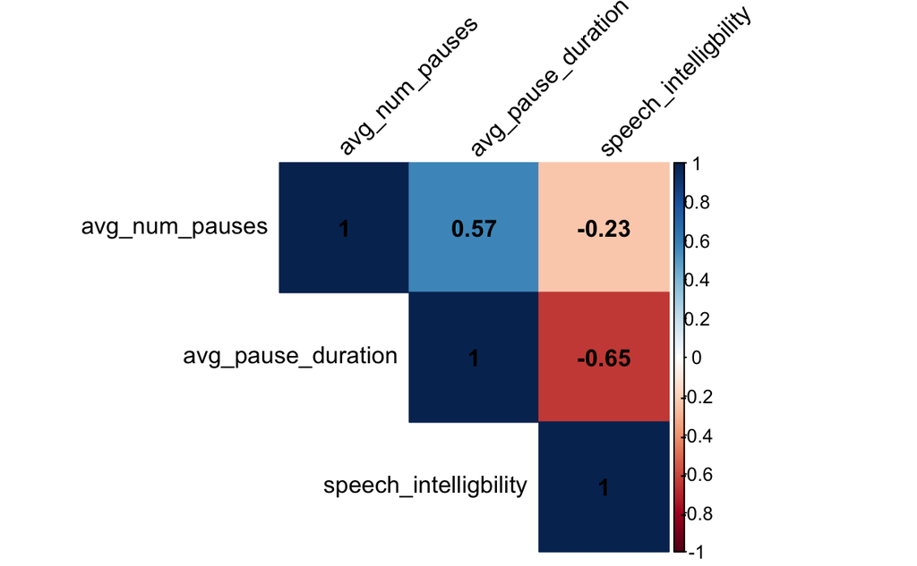

```r
corrplot(correlation_matrix,
         method = "color",
         type = "upper",
         tl.col = "black",
         tl.srt = 45,
         addCoef.col = "black")
```

# GLMER For Predicting Healthy vs. Patient Based on Pauses and Their Durations

In this section, we want to check, whether number of pauses or average pause duration could be good predictors of dysarthria speech.

We expect that average number of pauses would not be a significant predictor, while average pause duration would (due to previous correlation analysis).

To test this hypothesis, we build generalized linear mixed-effect regression. For this analysis, we use data file with information about each file’s number of pauses and their average duration.

```r
data <- read.csv('/Users/kirillkonca/Desktop/aggregated_file.csv')
```

Add participant groups: Patient vs Healthy Control

```r
data <- data %>%
  mutate(ParticipantGroup = ifelse(grepl("HC", Participant), "HealthyControl", "Patient"))
```

Dependent variable and random effect as factors

```r
data$ParticipantGroup <- factor(data$ParticipantGroup, levels = c("Patient", "HealthyControl"))
data$Participant <- as.factor(data$Participant)
```

```r
logreg_model <- glmer(
  ParticipantGroup ~ num_pauses + log(avg_pause_duration) + (1 | Participant),
  data = data,
  family = binomial(link = "logit")
)
```

Contrary to our expectations, nor number of pauses (Est. = -1.24; Std. Error = 2.17; p = 0.56), nor their duration (Est. = -4.13; Std. Error = 3.54; p = 0.24) is a significant predictor of dysarthria speech.

```r
summary(logreg_model)
```

```
Generalized linear mixed model fit by maximum likelihood (Laplace  Approximation)
 [glmerMod]
 Family: binomial  ( logit )
Formula: ParticipantGroup ~ num_pauses + log(avg_pause_duration) + (1 |
    Participant)
   Data: data

     AIC      BIC   logLik deviance df.resid
    44.5     64.4    -18.3     36.5     1077

Scaled residuals:
      Min        1Q    Median        3Q       Max
-0.048368 -0.005126 -0.001232  0.000275  0.001910

Random effects:
 Groups      Name        Variance Std.Dev.
 Participant (Intercept) 5785     76.06
Number of obs: 1081, groups:  Participant, 22

Fixed effects:
                        Estimate Std. Error z value Pr(>|z|)
(Intercept)               40.680     20.863   1.950   0.0512 .
num_pauses                -1.243      2.172  -0.572   0.5672
log(avg_pause_duration)   -4.128      3.540  -1.166   0.2436
---
Signif. codes:  0 ‘***’ 0.001 ‘**’ 0.01 ‘*’ 0.05 ‘.’ 0.1 ‘ ’ 1

Correlation of Fixed Effects:
            (Intr) nm_pss
num_pauses  -0.110
lg(vg_ps_d) -0.980 -0.052
```